# POPULATION DYNAMICS

This repository develops the logistic growth model from the scratch and its discrete, continuous, stochastic, and multi-species generalizations, alongside `R` implementations that simulate the resulting dynamics.

Each folder has a `README` that construct mathematical theory underlying that folder’s models, Which also contains some trajectory graphs, bifurcation diagrams etc. generated from the simulations.

Every script can be downloaded and run directly in `R`, along with any source files it imports.

#### Repository structure

$$\begin{align}
&[\text{Discrete time logistic growth model}]& \\
&\hspace{3cm} \downarrow & \\ &[\text{Continuous time
logistic growth model}]& \\ &\hspace{3cm} \downarrow & \\
&[ \text{ Holling functional - harvesting models}]& \\
&\hspace{3cm} \downarrow& \\ &[\text{Two Species -
population models}]&
\end{align}$$

#### On the theory:

The theory sections aim for mathematical rigor in definitions and are intended to be self-sufficient, though space constraints mean some notation is used loosely, and not every hypothesis is stated explicitly at the point it’s invoked. I’d suggest going through the models first to build intuition before working through the underlying theory — the equations tend to make more sense once you’ve watched them play out.

At some points, the construction may differ from a standard reference and reflects my own mathematical framing. If something reads as ambiguous, it likely is; I’d welcome corrections.

### Dynamical System :

State Space (Phase Space)  
The set of all possible values of a system’s state variables.

~Example: state variable := Population size.~

- $E \subset \mathbb{R}^n$ ~(or smooth manifolds in general).~
  - ~Single species:~ $E := \mathbb{R}_{\ge 0}$
  - $n$ <sub>species:</sub> $E := \mathbb{R}_{\ge 0}^n$

Dynamical functions  
Function that tells you the next state given the current state.

~In population dynamics;~ $T = \mathbb{Z}_{\ge 0}$ ~for discrete time, and~ $T = [0, \infty)$ ~for continuous time.~

Evolution function (discrete time)  
$F : E \to E$, s.t. $p_{t+1} = F(p_t)$ where $p_t$ is the system’s state at time $t \in \mathbb{Z}_{\ge 0}$.

Flow (discrete time)  
$\phi: T \times E \to E$, $(t, p) \rightarrow \phi_t(p)$ s.t. $\phi_t(p_0) := F^t(p_0)$ is defined as flow starting at state $p_0$. where $F^t := F \circ F \circ ... F, \text{ t-times}.$

Vector field (continuous time)  
$f : E \to \mathbb{R}^n$ s.t. $f(p) = dp/dt$. (maps each point in $E$ to its “velocity”)

Flow (continuous time)
$\phi: T \times E \to E$, $(t, p) \rightarrow \phi_t(p)$ is a flow generated by vector field $f$ on $E$ s. t.
$$\begin{aligned}
&\phi_0(p) = p & \forall p \in E\\
& \frac{\partial}{\partial t}\phi_t(p) = f(\phi_t(p)) & \forall
t \in T
\\
& \phi_{t+s}(p) = \phi_{t}(\phi_{s}(p)) = \phi_{s}(\phi_{t}(p))
\end{aligned}$$

So $\phi_t(p)$ is the state at time $t$ evolved under $\dot x = f(x)$ starting at $p$.

~Note: You can generalize time by taking~ $T := \mathbb{R}$ ~. For~ $T := \mathbb{R}_{\ge 0}$ ~we are only looking at the forward flow from given initial conditions.~

Trajectory and orbit
For a fixed initial condition $p_0 \in E$, trajectory through $p_0$ is a curve $\gamma_{p_0} : T \rightarrow E$, s.t.
$$\gamma_{p_0} (t) =
\phi_t(p_0)$$
And its Image $\{ \phi_t(p_0) | t \in T \} \subset E$ is the corresponding orbit.

~Parameter of dynamic function:~  
~A quantity~ $\mu$ ~(scalar or vector) that appears in the defining equation~ $\dot x=f(x;\mu)$ <sub>or</sub> $x_{n+1}=f (x_n;\mu)$ ~but is held fixed while the state~ $p$ ~evolves in time. e.g. max growth rate, max harvesting rate etc. set~ $M \subset \mathbb{R}^d$ ~of all~ $\mu$ ~is called parameter space~.

Fixed point / equilibrium  
A state $p^*$ that doesn’t change under the dynamics.  
Discrete: $p^* \in E$ s.t. $F(p^*) = p^*$.

Continuous: $p^* \in E$ s.t. $f(p^*) = 0$.

Stability of the Equilibrium  
~We have two definitions of stability, the latter being the stronger one.~

Lyapunov stable : Family $\{ \phi_t \}$ is Equicontinuous at point $p^*$.  
$\forall \varepsilon \gt 0, \exists \delta \gt 0$ s.t. $\boxed{ |p_0 - p^* | \lt \delta \implies | p_t - p^* | \lt \varepsilon, \forall t \ge 0}$

Small perturbation to $p^*$ stays small over the time.

**Asymptotically stable :** Family $\{ \phi_t \}$ is Equicontinuous at point $p^*$ and converges pointwise to $p^*$.  
$\boxed{\exists \delta_0 \ge 0 \text{ s.t. } |p_0 - p^* | \lt \delta_0 \implies p_t \to p^*}$

Small perturbation to $p^*$ stays small and eventually dies out over the time.

Equilibrium is local attractor.

Attractor  
$\omega -$limit set of $p_0$  
Set of all subsequential limits of the forward orbit of $p_0$.

$\omega (p_0) = \{ p \in E \ : \ \lim_{t_k \rightarrow \infty} \omega_{t_k}(p_0)= p, \ \text{ for any subsequence } (t_k)_{k \ge 0} \subset T \}$

Attracting Set $A(\mu)$
A non empty closed set $A = A(\mu) \subset E$ is an attracting set if
$$\begin{aligned}
a)& \ A \text{ is invariant under } \phi_t \text{ i.e. } \phi_t (A)
= A,
\forall t. \\
b)& \ \exists \text{ open } U, A \subset U \subset E, \text{ s.t.
}
\text{dist}( \phi_t (p_0), A) \rightarrow 0 \text{ as } t \rightarrow 0,
\ \forall p_0 \in U. \\
c)& \ \forall \varepsilon \gt 0, \exists \delta \gt 0 \text{ s.t. }
\text{dist}(p_0, A) \lt \delta \implies \text{dist}(\phi_t(p_0), A) \lt
\varepsilon, \ \forall t \ge 0.
\end{aligned}$$

$A(\mu)$ is an attractor if it is closed, invariant, Asymptotically stable (i.e. attracting and Lyapunov stable) and minimal set of such kind (no closed subset of A is attractor).

Here $\mu$ is a parameter value of the dynamic system $\dot x = f (x; \mu)$. For different $\mu$ we have may different $A$, $U$ structure even when the dynamic function has same form.

Basin of Attractor  
The entire region of starting points that will eventually get pulled into the attractor.

Attractor point  
$a \in A(\mu)$ is an attractor point.

Note: each $a \in \omega(p_0)$ for some $p_0 \in U$ and for each $p_0 \in U, \ \omega(p_0) \subset A$.

Types of attractors $A(\mu)$  
Fixed point : $A = \{ p^* \}$ i.e. equilibrium.

Periodic orbit : $A = \tau$ : closed curve with $\phi_T (p) = p, \ \forall p \in \tau$ : prey predator cycle etc.

Quasiperiodic attractor : oscillation with no exact period and dense orbit in A.

Chaotic attractor : bounded but unpredictable long-term behavior.

Bifurcation point  
Critical threshold in a parameter (growth rate, harvesting rate, infection rate etc.) where systems stability structure changes. (i.e. $A(\mu)$ changes in number, type or stability of attractors).

Let $M \subset \mathbb{R}^n$ be Parameter Space, $\mu_0 \in M$ is bifurcation point of $f(p; \mu)$ if every neighborhood $N$ of $\mu_0$ contains $\mu_1 , \mu_2$ s.t. no homeomorphism $h: E \rightarrow E$ maps orbits of $f(\cdot ; \mu_1)$ onto $f(\cdot; \mu_2)$ preserving the orientation (time-direction).

Bifurcation diagram  
A map of the system’s long-run states as a control parameter varies, marking where regime shifts occur.

$\mathcal{B} := \{ (\mu, p) \in M \times E : p \in A(\mu) \}$  
Curves distinguished by stability : solid = attractor, dashed = unstable invariant set. Plotted with $\mu$ on the x-axis and $p$ on y-axis.

### Determinism, Robustness, Predictability, and Attractor Structure :

Deterministic system  
Initial condition $p_0$ uniquely determines entire future trajectory $\phi_t(p_0)$. No stochasticity involved in the system.

Robustness  
$\mu \in M$ is robust if it’s not a bifurcation point. Stability structure is robust against perturbations in $\mu$.

Predictability at $p_0$  
If the measured initial condition has a small error $\delta_0$ can we determine how this error evolves over time? if small initial measurement error is forgiving i.e. it does not blow up into a large discrepancy, so the measured trajectory $\phi_t(x_0+\delta_0)$ remains a good approximation to the true trajectory $\phi_t(x_0)$. so we can still approximately predict future states of system. There are two distinct questions to focus. 1. are our predictions valid in time window $[0, t^*]$ ? 2. can we predict long run fate of system i.e. What happens to $\delta(t)$ as $t \to\infty$ ; does it eventually decay, drift, or grow without bound? This asymptotic question is answered by the Lyapunov exponent.

Let $p_0$ be true state and $p_0 + \delta_0$ be measured state, then we Define error at time $t$ as
$$\delta(t) := \phi_t(p_0 + \delta_0) -
\phi_t(p_0)$$

$(\varepsilon_{\text{tol}}, t^*)-$predictable at $p_0$
Let’s Fix tolerance $\varepsilon_\text{tol}>0$ and predictability horizon $t^*>0$. Define the system is $(\varepsilon_\text{tol}, t^*)-predictable$ at $p_0$ if,
$$\exists \xi \gt 0 \text{ s.t. } ||\delta(0)||
\lt \xi \implies ||\delta(t)|| \lt \varepsilon_\text{tol}, \ \forall t
\in [0, t^*]$$

Measurement error smaller than some threshold $\xi$  stays below the tolerance $\varepsilon_{\text{tol}}$ throughout the entire window $[0,t^*]$.

Lyapunov exponent  
Lets assume $||\delta(t)|| \approx e^{\lambda t}||\delta(0)||$ (by linearization of first order taylor expansion (as $f$ is $C^1$) of $f$ about $\phi_t(p_0)$.) This assumption is only valid on $[0, T]$ for $T$ not too large relative to $\ln(1/\|\delta(0)\|)$.

Here $\lambda$ is called Lyapunov constant. but taking logarithm of both side we define it as:

maximal Lyapunov exponent
$$\lambda(p_0) := \lim_{t \to \infty}
\lim_{|\delta_0| \to 0} \frac{1}
{t} \ln{\frac{|\delta(t)|}{|\delta(0)|}}$$

The limit $|\delta(0)| \to 0$ ensures validity of approximation at any time.

Discrete time Lyapunov exponent
$$\lambda(x_0) := \lim_{n \to \infty }
\frac{1}{n} \sum_{i = 0}^{n-1} \ln{|F'(p_i)|}$$

Lyapunov spectrum  
In $n$-dimensional phase space, we have $n$-basis directions along which we can make the perturbation in initial condition $p_0$ so we have $n$ Lyapunov exponents $\{ \lambda_i \}_n$ for each basis direction. I will upload pdf regarding the choice of basis (which not even an fixed orthogonal basis as standard sense) . `Work in progress`

Cases of $\lambda$

- $\lambda \lt 0$ : exponential decay of error in long run; but still we can have transient spikes at some finite t. This is exactly why $\lambda \lt 0$ does not imply Lyapunov stability in general.
- $\lambda = 0$ : linear/polynomial drift between trajectories i.e. phase/timing drift but no decay.
- $\lambda \gt 0$ : exponential growth of $\delta(t)$ (until gets bounded by some attractor structure)

  Predictability horizon for $\lambda \gt 0$  
  Let $\varepsilon_{\text{tol}}$ be fixed tolerance then for error $||\delta(t)|| \lt \varepsilon_\text{tol} \ \forall t \lt t^*$ where, $t^* = \frac{1}{\lambda} \ln \frac{\varepsilon_\text{tol} }{ \|\delta(0)\| }$

  Note: So $\lambda \gt 0$ and $t^*$ tell you the average/eventual rate — they do not certify smooth monotonic growth up to $t^*$. So we may still have transient spikes even at $t \lt t^*$.

Attractor structure  
For fixed $\mu$, $E$ decomposes as $E = \left(\bigsqcup_i U_i\right)\sqcup\Sigma$, : disjoint open basins $U_i$ of distinct minimal attractors $A_i(\mu)$ (possibly of different types simultaneously — multistability), plus a measure-zero exceptional set $\Sigma$ (basin boundaries, stable manifolds of saddles).

$A_i(\mu)$ need not be connected (e.g. period-$k$ points, multi-band chaotic attractors). Robustness/bifurcation is evaluated per-attractor: $\mu_0$ is a bifurcation point if the collection $\{A_i(\mu)\}$ changes in number, type, or stability as $\mu$ crosses $\mu_0$.

#### Attractor Structure flow chart:

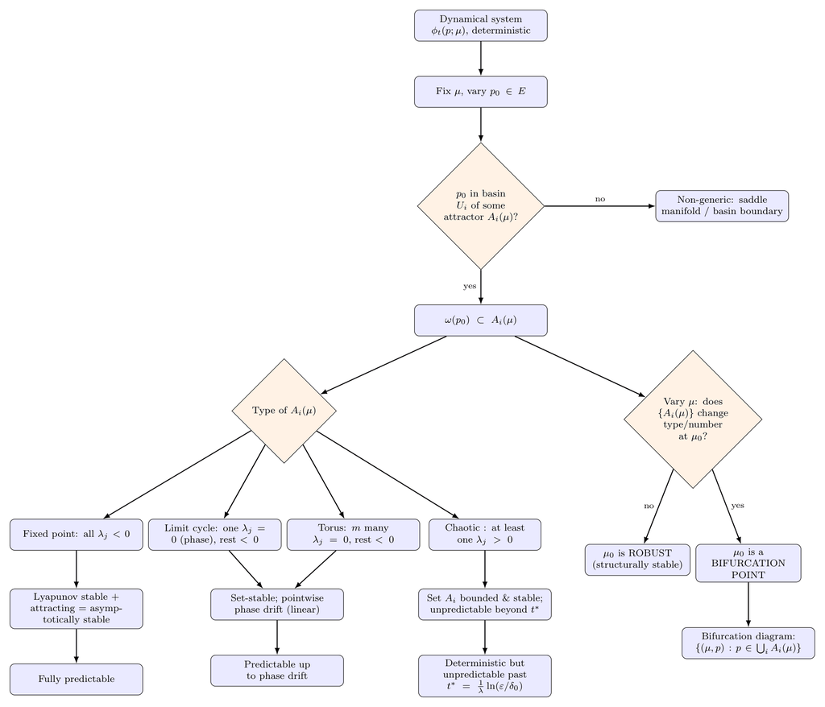

### References:

~*Perko, L. Differential Equations and Dynamical Systems, 3rd ed., Springer, 2001. §2.9 — attracting sets, Lyapunov stability, asymptotic stability; Poincaré maps for periodic orbits. Primary source for the core topological definitions used throughout.*~

~*Guckenheimer, J. & Holmes, P. Nonlinear Oscillations, Dynamical Systems, and Bifurcations of Vector Fields, Springer, 1983. Def. 1.1.2 and §1.2 — attracting sets with open neighborhoods, return/Poincaré maps, structural stability. Standard reference for bifurcation and limit-cycle stability arguments.*~

~*Kuznetsov, Y. A. Elements of Applied Bifurcation Theory, 3rd ed., Springer, 2004. Def. 2.1 — topological equivalence of vector fields; defines bifurcation as its failure. Source for the “no homeomorphism between orbit structures” formulation of a bifurcation point.*~

~*Milnor, J. “On the concept of attractor,” Communications in Mathematical Physics 99 (1985), 177–195; erratum 102 (1985), 517–519. Introduces the measure-theoretic (as opposed to topological/Lyapunov) definition of attractor — positive-measure, not-necessarily-open basin.*~

~*Alexander, J. C., Kan, I., Yorke, J. A., You, Z. “Riddled Basins,” International Journal of Bifurcation and Chaos 2 (1992), 795–813. Constructs basins of attraction that are positive-measure but nowhere dense/topologically riddled — the concrete counterexample motivating Milnor’s weaker definition.*~

~*Ashwin, P. & Timme, M. “Unstable attractors: existence and robustness in networks of oscillators with delayed pulse coupling,” Nonlinearity 18 (2005), 2035–2060. Source for “unstable attractors”: sets that are attracting (*~$\lim_{t\to\infty}$ ~*sense) but not Lyapunov stable, due to large transient excursions from non-normal dynamics.*~

~*Oseledets, V. I. “A multiplicative ergodic theorem: Lyapunov characteristic numbers for dynamical systems,” Transactions of the Moscow Mathematical Society 19 (1968), 197–231. Establishes existence of the Lyapunov spectrum and the associated (Oseledets) eigenbasis almost everywhere — the theoretical basis for defining*~ $\lambda_1,\dots,\lambda_n$ <sub>*rigorously.*</sub>

~*Katok, A. & Hasselblatt, B. Introduction to the Modern Theory of Dynamical Systems, Cambridge University Press, 1995. §4 — periodic orbits, recurrence,*~ $\omega$~*-limit sets; general reference for the topological/ergodic framework connecting invariance, recurrence, and attractors.*~